# Hmwk 3

Hunt Jones

2/4/2022

## Univariate Assignment

Read in tree data

```r
library(ggplot2)
library(gridExtra)
library(scatterplot3d)
library(MASS)
library(car)
# read in directly from website:
trees <- read.csv('https://raw.githubusercontent.com/dmcglinn/quant_methods/gh-pages/data/treedata_subset.csv')

str(trees)
```

```
## 'data.frame':    8038 obs. of  9 variables:
##  $ plotID    : chr  "ATBN-01-0403" "ATBN-01-0532" "ATBN-01-0533" "ATBN-01-0536" ...
##  $ spcode    : chr  "ABIEFRA" "ABIEFRA" "ABIEFRA" "ABIEFRA" ...
##  $ species   : chr  "Abies fraseri" "Abies fraseri" "Abies fraseri" "Abies fraseri" ...
##  $ cover     : int  1 8 3 3 5 2 4 8 8 5 ...
##  $ elev      : num  1660 1712 1722 1754 1570 ...
##  $ tci       : num  5.7 3.82 3.89 3.15 11.85 ...
##  $ streamdist: num  491 454 453 492 0 ...
##  $ disturb   : chr  "CORPLOG" "VIRGIN" "LT-SEL" "SETTLE" ...
##  $ beers     : num  0.224 0.834 1.333 1.471 0.496 ...
```

Examine this dataset and see how the data is structured, see function ‘str’

The contents of the metadata file (./data/tree_metadata.txt(https://raw.githubusercontent.com/dmcglinn/quant_methods/gh-pages/data/tree_metadata.txt)) is provided here:

The dataset includes tree abundances from a subset of a vegetation database of Great Smoky Mountains National Park (TN, NC).

- plotID: unique code for each spatial unit (note some sampled more than once)
- date: when species occurrence recorded
- plotsize: size of quadrat in m2
- spcode: unique 7-letter code for each species
- species: species name
- cover: local abundance measured as estimated horizontal cover (ie, relative area of shadow if sun is directly above) classes 1-10 are: 1=trace, 2=0-1%, 3=1-2%, 4=2-5%, 5=5-10%, 6=10-25%, 7=25-50%, 8=50-75%, 9=75-95%, 10=95-100%
- utme: plot UTM Easting, zone 17 (NAD27 Datum)
- utmn: plot UTM Northing, zone 17 (NAD27 Datum)
- elev: elevation in meters from a digital elevation model (10 m res)
- tci: topographic convergence index, or site “water potential”; measured as the upslope contributing area divided by the tangent of the slope angle (Beven and Kirkby 1979)
- streamdist: distance of plot from the nearest permanent stream (meters)
- disturb: plot disturbance history (from a Park report); CORPLOG=corporate logging; SETTLE=concentrated settlement, VIRGIN=“high in virgin attributes”, LT-SEL=light or selective logging
- beers: transformed slope aspect (‘heat load index’); 0 is SW (hottest), 2 is NE (coolest)

1. Carry out an exploratory analysis using the tree dataset. CHECK

Metadata for the tree study can be found here(../data/tree_metadata.txt).

Specifically, I would like you to develop and compare models for species cover for a habitat generalist Acer rubrum

and a habitat specialist Abies fraseri

Because this dataset includes both continuous and discrete explanatory variables use the function Anova in the packages car as such

```r
explore <- trees[c( which(trees$species == "Abies fraseri"), which(trees$species == "Acer rubrum")), ]
abies <- trees[which(trees$species == "Abies fraseri"), ]
acer <- trees[which(trees$species == "Acer rubrum"), ]
```

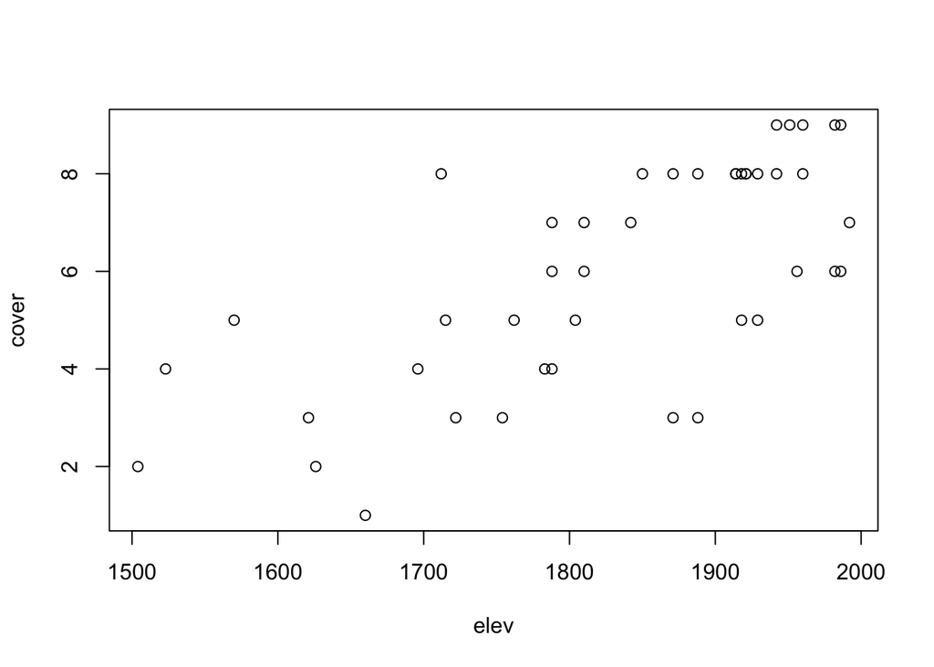

```r
abies$disturb <- as.factor(abies$disturb) # treat disturbance as a factor

abies$disturb <- factor(abies$disturb, levels = c("VIRGIN", "CORPLOG", "LT-SEL", "SETTLE"))
# this reorders the disturbance factors so that when we run the 'summary' function,
# CORPLOG, LT-SEL, and SETTLE are each compared to VIRGIN (VIRGIN essentially
# becomes the null hypothesis.

plot(cover ~ elev, data = abies)
```

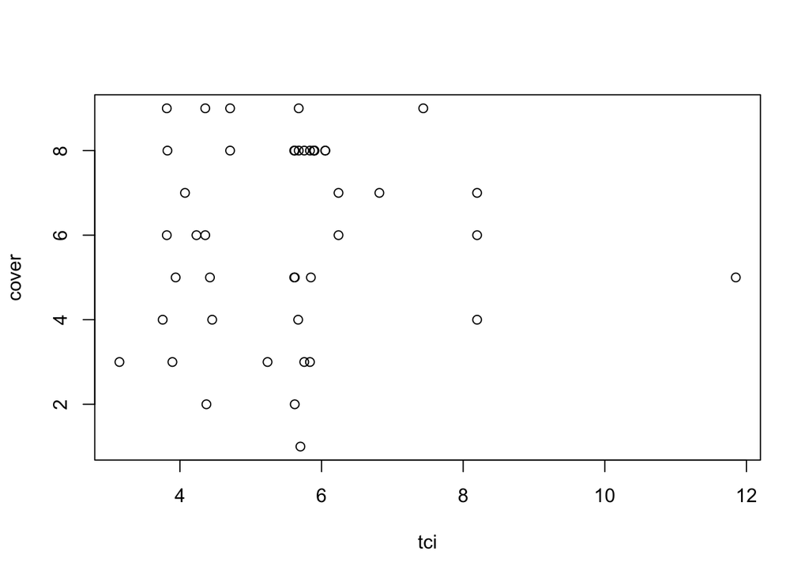

```r
plot(cover ~ tci, data = abies)
```

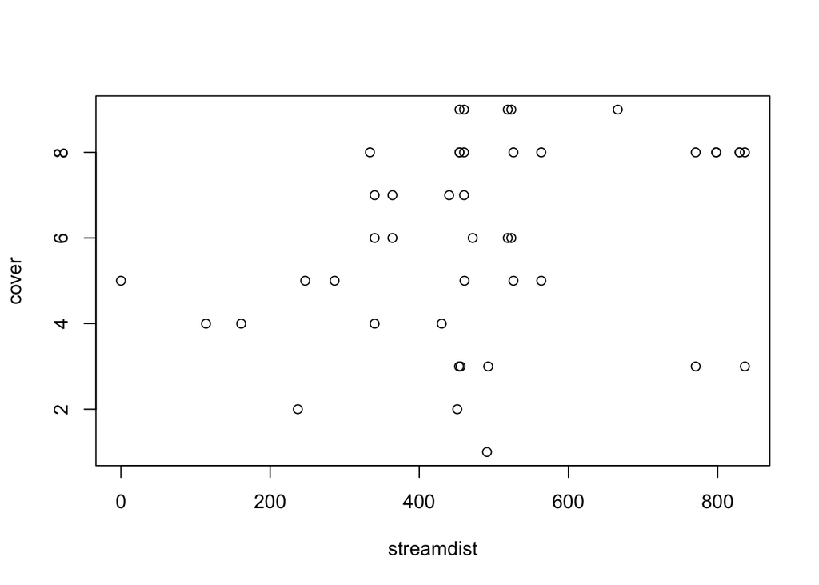

```r
plot(cover ~ streamdist, data = abies)
```

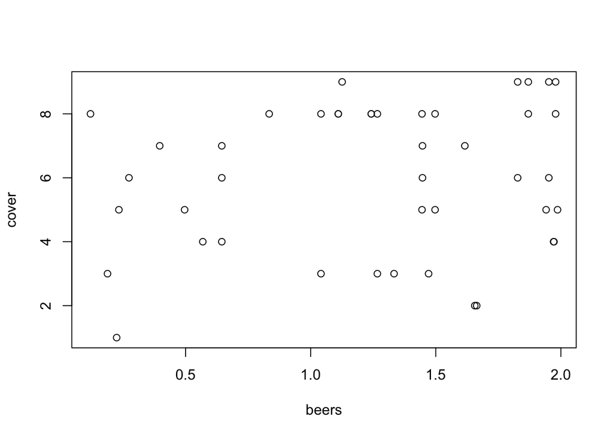

```r
plot(cover ~ beers, data = abies)        # plot each variable independently to
```

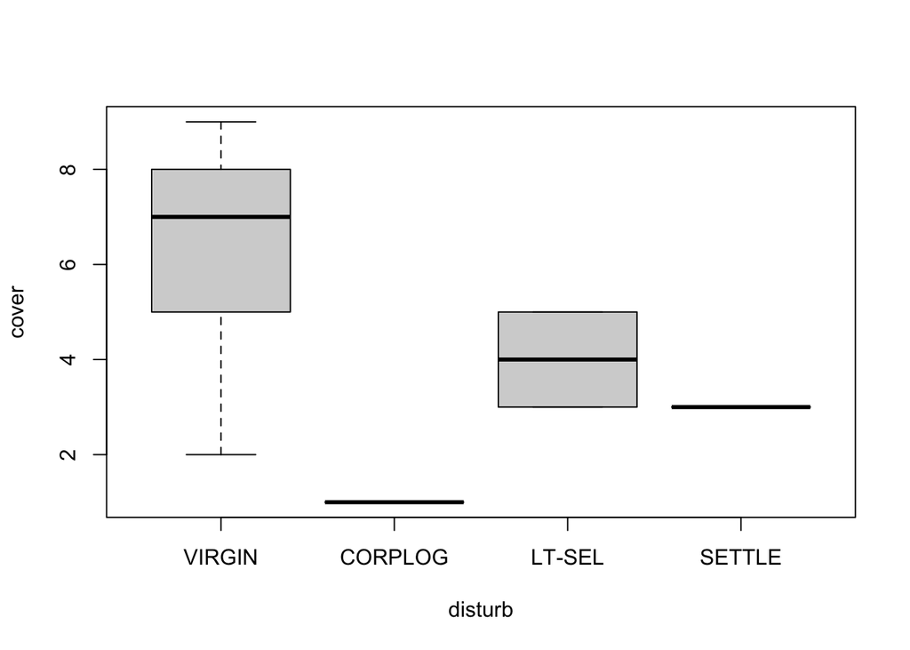

```r
plot(cover ~ disturb, data = abies)      # look for signal in graphs
```

```r
# based on the output of these graphs, prior to making my model, I would expect
# to see a significant effect of elevation on cover, and another one by distance
# to the nearest stream, though I would expect the effect of elevation on cover
# to be stronger. I expect no significant effect of beers or tci on cover.
# For the disturbance levels, expect that there might be a significant difference
# between the VIRGIN and CORPLOG data, but there is such high variance in the
# VIRGIN data that the difference may not be statistically significant.
```

```r
abies_mod <- lm(cover ~ elev + tci + streamdist + beers + disturb, data = abies)
abies_mod   # creates our univariate model with cover as the response, which
```

```
##
## Call:
## lm(formula = cover ~ elev + tci + streamdist + beers + disturb,
##     data = abies)
##
## Coefficients:
##    (Intercept)            elev             tci      streamdist           beers
##     -17.535577        0.012370        0.287641       -0.001266        0.037551
## disturbCORPLOG   disturbLT-SEL   disturbSETTLE
##      -3.025596       -0.837228       -1.497992
```

```r
            # evaluates the effect of each independent variable individually
            # and compares it to the others
```

```r
Anova(abies_mod, type = 3)
```

```
## Anova Table (Type III tests)
##
## Response: cover
##             Sum Sq Df F value    Pr(>F)
## (Intercept) 40.790  1 15.9113 0.0003114 ***
## elev        61.618  1 24.0358 2.022e-05 ***
## tci          5.667  1  2.2105 0.1457819
## streamdist   1.636  1  0.6382 0.4296008
## beers        0.014  1  0.0056 0.9405811
## disturb     10.089  3  1.3118 0.2855474
## Residuals   92.289 36
## ---
## Signif. codes:  0 '***' 0.001 '**' 0.01 '*' 0.05 '.' 0.1 ' ' 1
```

```r
summary(abies_mod)
```

```
##
## Call:
## lm(formula = cover ~ elev + tci + streamdist + beers + disturb,
##     data = abies)
##
## Residuals:
##     Min      1Q  Median      3Q     Max
## -3.4630 -0.6472  0.0788  1.0872  3.8017
##
## Coefficients:
##                  Estimate Std. Error t value Pr(>|t|)
## (Intercept)    -17.535577   4.396091  -3.989 0.000311 ***
## elev             0.012370   0.002523   4.903 2.02e-05 ***
## tci              0.287641   0.193467   1.487 0.145782
## streamdist      -0.001266   0.001585  -0.799 0.429601
## beers            0.037551   0.500269   0.075 0.940581
## disturbCORPLOG  -3.025596   1.735921  -1.743 0.089882 .
## disturbLT-SEL   -0.837228   1.292731  -0.648 0.521325
## disturbSETTLE   -1.497992   1.693416  -0.885 0.382244
## ---
## Signif. codes:  0 '***' 0.001 '**' 0.01 '*' 0.05 '.' 0.1 ' ' 1
##
## Residual standard error: 1.601 on 36 degrees of freedom
## Multiple R-squared:  0.5824, Adjusted R-squared:  0.5011
## F-statistic: 7.171 on 7 and 36 DF,  p-value: 2.215e-05
```

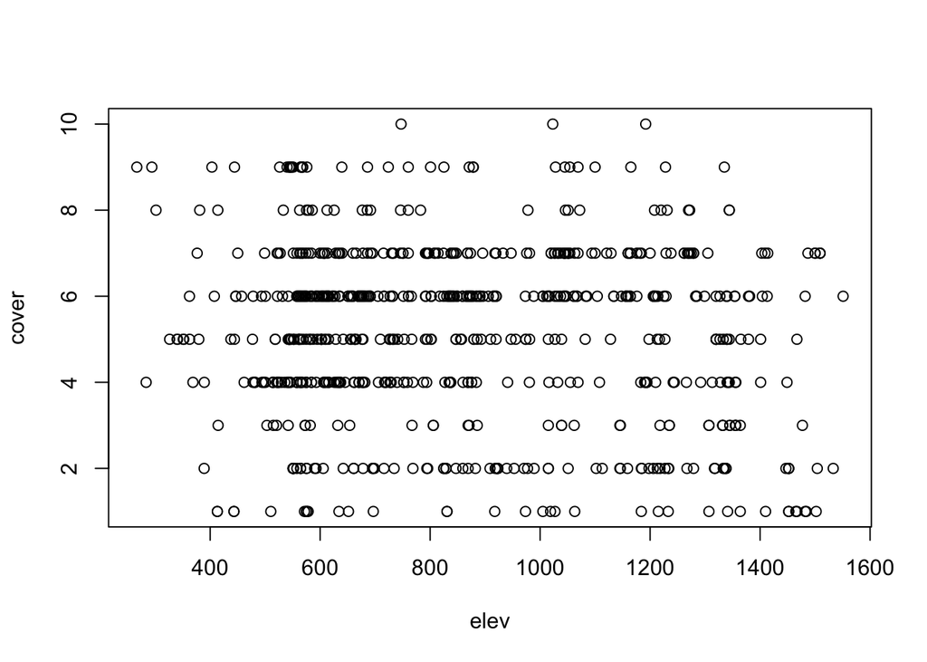

```r
acer$disturb <- as.factor(acer$disturb)

acer$disturb <- factor(acer$disturb, levels = c("VIRGIN", "CORPLOG", "LT-SEL", "SETTLE"))

plot(cover ~ elev, data = acer)
```

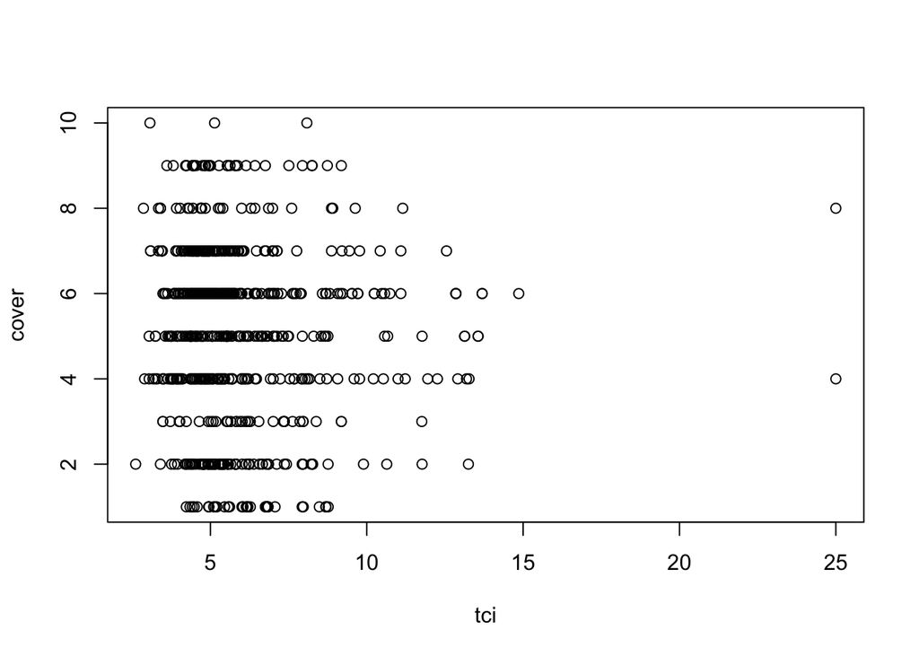

```r
plot(cover ~ tci, data = acer)
```

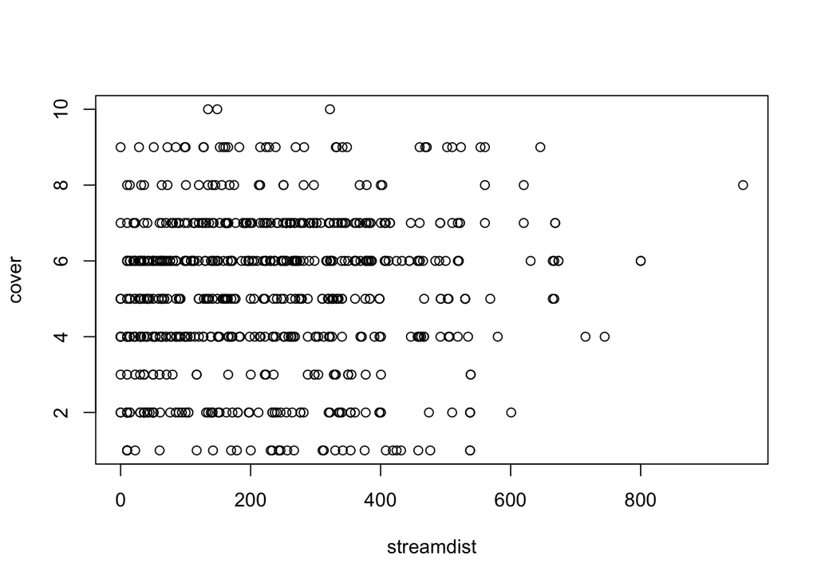

```r
plot(cover ~ streamdist, data = acer)
```

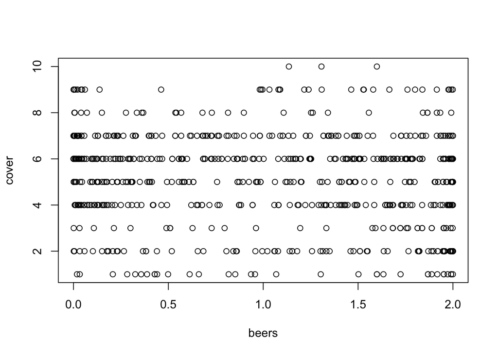

```r
plot(cover ~ beers, data = acer)
```

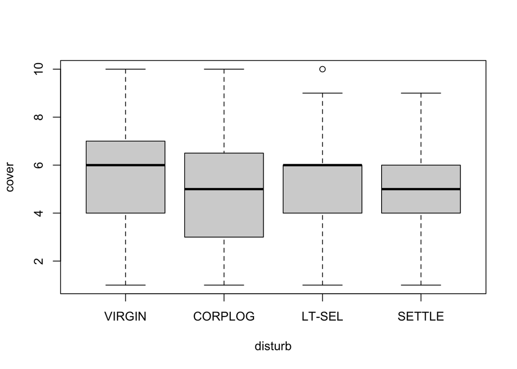

```r
plot(cover ~ disturb, data = acer)
```

```r
# my expectations for the acer data are quite different than that of Abies fraseri.
# I expect no significant effect of any of the independent variables included
# on cover, and I expect to find no significant difference in cover among the
# samples taken from areas with different disturbance levels.
```

```r
acer_mod <- lm(cover ~ elev + tci + streamdist + beers + disturb, data = acer)
acer_mod
```

```
##
## Call:
## lm(formula = cover ~ elev + tci + streamdist + beers + disturb,
##     data = acer)
##
## Coefficients:
##    (Intercept)            elev             tci      streamdist           beers
##       6.659067       -0.001011       -0.062761        0.001290       -0.326960
## disturbCORPLOG   disturbLT-SEL   disturbSETTLE
##      -0.308836       -0.225875       -0.413292
```

```r
Anova(acer_mod, type=3)
```

```
## Anova Table (Type III tests)
##
## Response: cover
##              Sum Sq  Df  F value    Pr(>F)
## (Intercept)  815.29   1 206.1126 < 2.2e-16 ***
## elev          40.44   1  10.2233  0.001448 **
## tci           12.58   1   3.1805  0.074947 .
## streamdist    29.09   1   7.3531  0.006856 **
## beers         35.61   1   9.0034  0.002789 **
## disturb        9.45   3   0.7962  0.496166
## Residuals   2828.21 715
## ---
## Signif. codes:  0 '***' 0.001 '**' 0.01 '*' 0.05 '.' 0.1 ' ' 1
```

```r
summary(acer_mod)
```

```
##
## Call:
## lm(formula = cover ~ elev + tci + streamdist + beers + disturb,
##     data = acer)
##
## Residuals:
##     Min      1Q  Median      3Q     Max
## -4.7073 -1.2446  0.3409  1.3575  5.2732
##
## Coefficients:
##                  Estimate Std. Error t value Pr(>|t|)
## (Intercept)     6.6590668  0.4638324  14.357  < 2e-16 ***
## elev           -0.0010108  0.0003161  -3.197  0.00145 **
## tci            -0.0627613  0.0351922  -1.783  0.07495 .
## streamdist      0.0012895  0.0004756   2.712  0.00686 **
## beers          -0.3269597  0.1089662  -3.001  0.00279 **
## disturbCORPLOG -0.3088364  0.2518161  -1.226  0.22044
## disturbLT-SEL  -0.2258754  0.2393303  -0.944  0.34560
## disturbSETTLE  -0.4132920  0.2995952  -1.380  0.16817
## ---
## Signif. codes:  0 '***' 0.001 '**' 0.01 '*' 0.05 '.' 0.1 ' ' 1
##
## Residual standard error: 1.989 on 715 degrees of freedom
## Multiple R-squared:  0.04493,    Adjusted R-squared:  0.03558
## F-statistic: 4.805 on 7 and 715 DF,  p-value: 2.669e-05
```

This will estimate partial effect sizes, variance explained, and p-values for each explanatory variable included in the model.

Compare the p-values you observe using the function ‘Anova’ to those generated using ‘summary’. All p-values are the same for both Anova and summary except for that of the disturbance factor. Anova runs one test comparing all disturbance types at once, while summary compares each disturbance type to the VIRGIN group, which serves as the null hypothesis.

For each species address the following additional questions:

- how well does the exploratory model appear to explain cover? Abies fraseri: the exploratory model indicates that elevation is the best variable to explain cover. Elevation was the only explanatory variable with a significant relationship to cover. The main reason that this model shows promise, however, is that the r-squared is fairly high, especially for data collected in the field rather than a controlled lab setting. However, the adjusted r-squred value is lower than the r-squared value by about 0.08, which means that some overfitting has occurred and this model would probably be a better model if it included fewer explanatory variables.

  Acer rubrum: the exploratory model for acer rubrum does not explain cover very well. While several explanatory variables were found to have a significant relationship with cover, the r-squared value was very low, meaning that the explanatory variables do not explain much of the variance in the cover data. On top of that, the adjusted r-squared is lower than the r-squared. Although it is only slightly lower, the r-squared value here is so low that even a small decrease might indicate overfitting.
- which explanatory variables are the most important? the most important explanatory variable in each model appears to be elevation.
- do model diagnostics indicate any problems with violations of OLS assumptions?

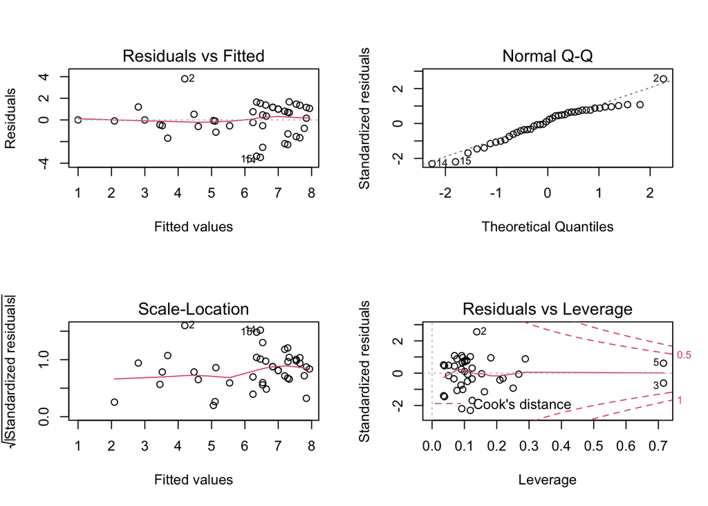

```r
par(mfrow = c(2,2))
plot(abies_mod)
```

```r
# The data appear to be linear, the residuals are normally distributed. However,
# homoscedasticity is questionable because the data re not evenly spread. The
# data do not appear to be leveraged, as the standardized residuals are within
# 3 standard deviations, meaning that no outliers exist that might alter the
# interpretation of our data, though if I am being honest, I still have a hard
# time understanding how to assess this violation.
```

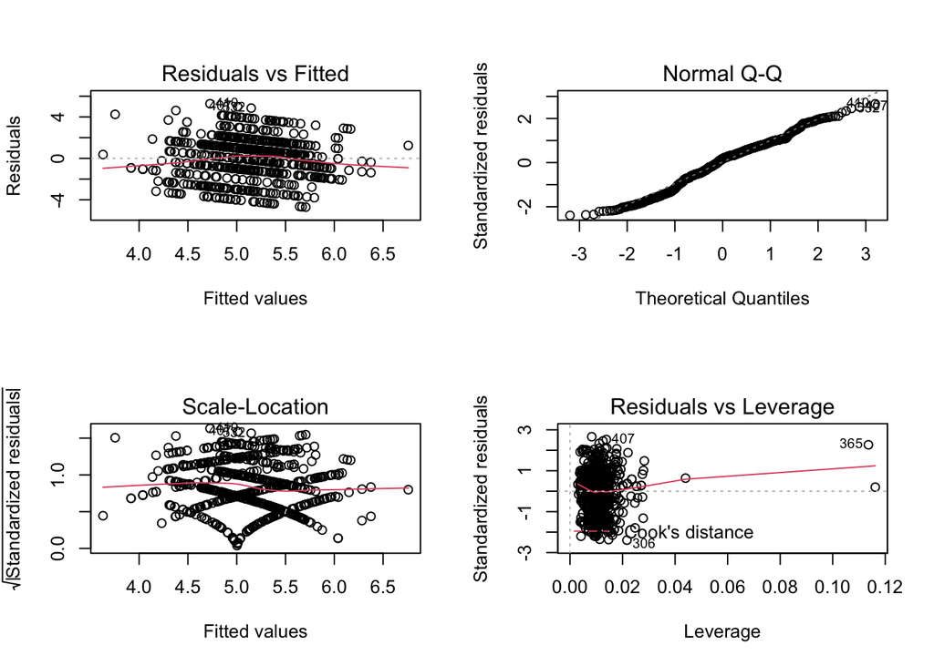

```r
par(mfrow = c(2,2))
plot(acer_mod)
```

```r
# The residuals vs fitted appear to indicate that the data is linear, though
# they are not perfect. The residuals appear to be normally distributed. The
# data to not appear to have homoscedasticity. And the data appear to be
# levearaged with several outliers.
```

- are you able to explain variance in one species better than another, why might this be the case?

  Yes, we can explain variance in Abies fraseri better. This might be because fewer of this species of tree were observed. Often, when there is a large sample size, significant relationships might be identified despite low r-squared.
2. You may have noticed that the variable cover is defined as positive integers between 1 and 10. and is therefore better treated as a discrete rather than continuous variable. Re-examine your solutions to the question above but from the perspective of a General Linear Model (GLM) with a Poisson error term (rather than a Gaussian one as in OLS). The Poisson distribution generates integers 0 to positive infinity so this may provide a good first approximation. Your new model calls will look as follows:

```r
acer_poi <- glm(cover ~ elev + tci + streamdist + beers + disturb, data = acer, family = poisson)
acer_poi
```

```
##
## Call:  glm(formula = cover ~ elev + tci + streamdist + beers + disturb,
##     family = poisson, data = acer)
##
## Coefficients:
##    (Intercept)            elev             tci      streamdist           beers
##      1.9361234      -0.0001961      -0.0129660       0.0002428      -0.0639106
## disturbCORPLOG   disturbLT-SEL   disturbSETTLE
##     -0.0631125      -0.0447152      -0.0804981
##
## Degrees of Freedom: 722 Total (i.e. Null);  715 Residual
## Null Deviance:       649.3
## Residual Deviance: 623.4     AIC: 3102
```

```r
Anova(acer_poi, type=3)
```

```
## Analysis of Deviance Table (Type III tests)
##
## Response: cover
##            LR Chisq Df Pr(>Chisq)
## elev         7.7744  1   0.005299 **
## tci          2.5877  1   0.107699
## streamdist   5.4866  1   0.019163 *
## beers        6.9611  1   0.008330 **
## disturb      1.9033  3   0.592714
## ---
## Signif. codes:  0 '***' 0.001 '**' 0.01 '*' 0.05 '.' 0.1 ' ' 1
```

```r
summary(acer_poi)
```

```
##
## Call:
## glm(formula = cover ~ elev + tci + streamdist + beers + disturb,
##     family = poisson, data = acer)
##
## Deviance Residuals:
##     Min       1Q   Median       3Q      Max
## -2.4282  -0.5903   0.1391   0.5786   2.1038
##
## Coefficients:
##                  Estimate Std. Error z value Pr(>|z|)
## (Intercept)     1.936e+00  1.038e-01  18.644  < 2e-16 ***
## elev           -1.961e-04  7.047e-05  -2.783  0.00538 **
## tci            -1.297e-02  8.159e-03  -1.589  0.11202
## streamdist      2.428e-04  1.030e-04   2.357  0.01843 *
## beers          -6.391e-02  2.423e-02  -2.638  0.00834 **
## disturbCORPLOG -6.311e-02  5.638e-02  -1.119  0.26293
## disturbLT-SEL  -4.472e-02  5.302e-02  -0.843  0.39900
## disturbSETTLE  -8.050e-02  6.626e-02  -1.215  0.22441
## ---
## Signif. codes:  0 '***' 0.001 '**' 0.01 '*' 0.05 '.' 0.1 ' ' 1
##
## (Dispersion parameter for poisson family taken to be 1)
##
##     Null deviance: 649.34  on 722  degrees of freedom
## Residual deviance: 623.38  on 715  degrees of freedom
## AIC: 3101.8
##
## Number of Fisher Scoring iterations: 4
```

```r
abies_poi <- glm(cover ~ elev + tci + streamdist + beers + disturb, data = abies, family = poisson)
abies_poi
```

```
##
## Call:  glm(formula = cover ~ elev + tci + streamdist + beers + disturb,
##     family = poisson, data = abies)
##
## Coefficients:
##    (Intercept)            elev             tci      streamdist           beers
##     -2.7154015       0.0023508       0.0568868      -0.0002186      -0.0165548
## disturbCORPLOG   disturbLT-SEL   disturbSETTLE
##     -1.4002993      -0.1562986      -0.3562761
##
## Degrees of Freedom: 43 Total (i.e. Null);  36 Residual
## Null Deviance:       41.27
## Residual Deviance: 16.13     AIC: 189.3
```

```r
Anova(abies_poi, type=3)
```

```
## Analysis of Deviance Table (Type III tests)
##
## Response: cover
##            LR Chisq Df Pr(>Chisq)
## elev        11.3450  1  0.0007565 ***
## tci          1.1830  1  0.2767545
## streamdist   0.3059  1  0.5802166
## beers        0.0155  1  0.9008297
## disturb      3.3953  3  0.3346007
## ---
## Signif. codes:  0 '***' 0.001 '**' 0.01 '*' 0.05 '.' 0.1 ' ' 1
```

```r
summary(abies_poi)
```

```
##
## Call:
## glm(formula = cover ~ elev + tci + streamdist + beers + disturb,
##     family = poisson, data = abies)
##
## Deviance Residuals:
##      Min        1Q    Median        3Q       Max
## -1.47931  -0.35524   0.08027   0.36453   1.69535
##
## Coefficients:
##                  Estimate Std. Error z value Pr(>|z|)
## (Intercept)    -2.7154015  1.3167053  -2.062  0.03918 *
## elev            0.0023508  0.0007292   3.224  0.00126 **
## tci             0.0568868  0.0524222   1.085  0.27785
## streamdist     -0.0002186  0.0003969  -0.551  0.58176
## beers          -0.0165548  0.1326724  -0.125  0.90070
## disturbCORPLOG -1.4002993  1.0171140  -1.377  0.16859
## disturbLT-SEL  -0.1562986  0.4031913  -0.388  0.69827
## disturbSETTLE  -0.3562761  0.6006287  -0.593  0.55307
## ---
## Signif. codes:  0 '***' 0.001 '**' 0.01 '*' 0.05 '.' 0.1 ' ' 1
##
## (Dispersion parameter for poisson family taken to be 1)
##
##     Null deviance: 41.274  on 43  degrees of freedom
## Residual deviance: 16.126  on 36  degrees of freedom
## AIC: 189.3
##
## Number of Fisher Scoring iterations: 4
```

For assessing the degree of variation explained you can use a pseudo-R-squared statistic (note this is just one of many possible)

```r
pseudo_r2 = function(glm_mod) {
                1 -  glm_mod$deviance / glm_mod$null.deviance
}

pseudo_r2(acer_poi)
```

```
## [1] 0.03997917
```

```r
pseudo_r2(abies_poi)
```

```
## [1] 0.60931
```

Compare your qualatitive assessment of which variables were most important in each model. Does it appear that changing the error distribution changed the results much? In what ways?

3. Provide a plain English summary (i.e., no statistics) of what you have found and what conclusions we can take away from your analysis?

What we have found is that elevation appears to be the primary factor of value in predicting any effect on cover. For Abies fraseri, using elevation as a predictor of cover will produce fairly reliable results. However, using elevation as a predictor of cover for Acer rubrum will not provide very reliable results.

4. (optional) Examine the behavior of the function ‘stepAIC()’ using the exploratory models developed above. This is a very simple and not very robust machine learning stepwise algorithm that uses AIC to select a best model. By default it does a backward selection routine.

```r
stepAIC(acer_mod)
```

```
## Start:  AIC=1002.17
## cover ~ elev + tci + streamdist + beers + disturb
##
##              Df Sum of Sq    RSS     AIC
## - disturb     3     9.449 2837.7  998.58
## <none>                    2828.2 1002.17
## - tci         1    12.581 2840.8 1003.37
## - streamdist  1    29.085 2857.3 1007.56
## - beers       1    35.613 2863.8 1009.21
## - elev        1    40.439 2868.7 1010.43
##
## Step:  AIC=998.58
## cover ~ elev + tci + streamdist + beers
##
##              Df Sum of Sq    RSS     AIC
## <none>                    2837.7  998.58
## - tci         1    14.370 2852.0 1000.23
## - streamdist  1    31.491 2869.2 1004.56
## - beers       1    35.515 2873.2 1005.57
## - elev        1    45.778 2883.4 1008.15
```

```
##
## Call:
## lm(formula = cover ~ elev + tci + streamdist + beers, data = acer)
##
## Coefficients:
## (Intercept)         elev          tci   streamdist        beers
##   6.3218898   -0.0008868   -0.0668631    0.0013256   -0.3204370
```

```r
stepAIC(acer_poi)
```

```
## Start:  AIC=3101.77
## cover ~ elev + tci + streamdist + beers + disturb
##
##              Df Deviance    AIC
## - disturb     3   625.28 3097.7
## <none>            623.38 3101.8
## - tci         1   625.97 3102.4
## - streamdist  1   628.87 3105.2
## - beers       1   630.34 3106.7
## - elev        1   631.16 3107.5
##
## Step:  AIC=3097.67
## cover ~ elev + tci + streamdist + beers
##
##              Df Deviance    AIC
## <none>            625.28 3097.7
## - tci         1   628.24 3098.6
## - streamdist  1   631.22 3101.6
## - beers       1   632.24 3102.6
## - elev        1   634.11 3104.5
```

```
##
## Call:  glm(formula = cover ~ elev + tci + streamdist + beers, family = poisson,
##     data = acer)
##
## Coefficients:
## (Intercept)         elev          tci   streamdist        beers
##   1.8700348   -0.0001719   -0.0138226    0.0002500   -0.0626543
##
## Degrees of Freedom: 722 Total (i.e. Null);  718 Residual
## Null Deviance:       649.3
## Residual Deviance: 625.3     AIC: 3098
```

```r
stepAIC(abies_mod)
```

```
## Start:  AIC=48.59
## cover ~ elev + tci + streamdist + beers + disturb
##
##              Df Sum of Sq     RSS    AIC
## - beers       1     0.014  92.304 46.599
## - disturb     3    10.089 102.379 47.157
## - streamdist  1     1.636  93.926 47.366
## <none>                     92.289 48.593
## - tci         1     5.667  97.956 49.215
## - elev        1    61.618 153.908 69.095
##
## Step:  AIC=46.6
## cover ~ elev + tci + streamdist + disturb
##
##              Df Sum of Sq     RSS    AIC
## - streamdist  1     1.665  93.969 45.386
## - disturb     3    10.679 102.983 45.417
## <none>                     92.304 46.599
## - tci         1     6.745  99.049 47.703
## - elev        1    64.662 156.966 67.961
##
## Step:  AIC=45.39
## cover ~ elev + tci + disturb
##
##           Df Sum of Sq     RSS    AIC
## - disturb  3    12.021 105.990 44.683
## <none>                  93.969 45.386
## - tci      1     6.807 100.776 46.463
## - elev     1    78.687 172.656 70.153
##
## Step:  AIC=44.68
## cover ~ elev + tci
##
##        Df Sum of Sq    RSS    AIC
## <none>              105.99 44.683
## - tci   1     9.239 115.23 46.360
## - elev  1   114.046 220.04 74.822
```

```
##
## Call:
## lm(formula = cover ~ elev + tci, data = abies)
##
## Coefficients:
## (Intercept)         elev          tci
##   -18.78984      0.01262      0.30454
```

```r
stepAIC(abies_poi)
```

```
## Start:  AIC=189.3
## cover ~ elev + tci + streamdist + beers + disturb
##
##              Df Deviance    AIC
## - disturb     3   19.521 186.70
## - beers       1   16.141 187.32
## - streamdist  1   16.431 187.61
## - tci         1   17.308 188.49
## <none>            16.125 189.30
## - elev        1   27.471 198.65
##
## Step:  AIC=186.7
## cover ~ elev + tci + streamdist + beers
##
##              Df Deviance    AIC
## - beers       1   19.533 184.71
## - streamdist  1   20.014 185.19
## - tci         1   21.459 186.64
## <none>            19.521 186.70
## - elev        1   35.334 200.51
##
## Step:  AIC=184.71
## cover ~ elev + tci + streamdist
##
##              Df Deviance    AIC
## - streamdist  1   20.055 183.23
## <none>            19.533 184.71
## - tci         1   21.731 184.91
## - elev        1   37.364 200.54
##
## Step:  AIC=183.23
## cover ~ elev + tci
##
##        Df Deviance    AIC
## <none>      20.055 183.23
## - tci   1   22.180 183.36
## - elev  1   41.120 202.30
```

```
##
## Call:  glm(formula = cover ~ elev + tci, family = poisson, data = abies)
##
## Coefficients:
## (Intercept)         elev          tci
##   -3.137624     0.002469     0.065410
##
## Degrees of Freedom: 43 Total (i.e. Null);  41 Residual
## Null Deviance:       41.27
## Residual Deviance: 20.06     AIC: 183.2
```

5. (optional) Develop a model for the number of species in each site (i.e., unique plotID). This variable will also be discrete so the Poisson may be a good starting approximation. Side note: the Poisson distribution converges asymptotically on the Gaussian distribution as the mean of the distribution increases. Thus Poisson regression does not differ much from traditional OLS when means are large.